# Series de Conexiones a Internet Móvil en Chile

Sebastián Celaya

14-11-2021

Dentro del siguiente trabajo analizaremos los datos que tenemos acerca de las series de conexiones a internet móvil (conocidas también como “datos móviles”) que hay en Chile, separándolas por año, compañía y tipo de plan, de esta manera encontrar algún tipo de relación con estos datos.

Estos datos son muy importantes ya que hoy en día las reces sociales son primordiales para la calidad de vida para los humanos, y para poder tener esto necesitamos de conexiones a internet. Además cabe decir de que las personas prefieren tener el internet en cualquier momento y lugar, por eso es primordial poder observar los datos de las conexiones internet móvil, esto nos dará antecedentes para que las personas a futuro puedan ver si es posible iniciar una nueva empresa que maneje conexiones móviles o para quienes quieren obtener alguna de estas conexiones y no tenga base para ello, este informe ayudará mucho para esas decisiones.

Con estos datos podremos evaluar las situaciones y darles sentido según el contexto de cada año o compañía que analizamos, para así poder estimar los datos que vendrán a futuro.

En este texto encontrás los resultados obtenidos de la investigación y seguido, de vez en cuando, por algún gráfico o material visual para mejorar el entendimiento de este tema. También habrá partes donde veamos algunas creencias de causa y efecto de situaciones las cuales vamos a validar o mostrar lo contrario con los datos que tenemos.

Las conexiones a internet móvil en Chile se pueden distinguir de 3 tipos: 2G, 3G, y 4G. Las cuales se diferencian en la calidad, velocidad y seguridad de la conexión a internet, siendo la 2G la de menor calidad, velocidad y seguridad, mientras que la 4G hasta hace poco es la de mayor calidad, velocidad y seguridad. Actualmente se está implementando una conexión 5G que supera los estándares del 4G, pero todavía no lo lanzan al público en general las grandes empresas.

En la historia de Chile, existen 3 compañías que han existido desde los inicios de las conexiones a internet en general, que son Movistar, Entel y Claro. Y en esos tiempos se fueron generando muchas otras empresas, pero que no tenían tanto impacto como los 3 antes mencionados, de hecho en los ultimos años, muchas de estas empresas estan sufriendo una gran caída del número de usuarios debido a la poca eficiencia de su servicio o la poca publicidad que estos generan.

Durante este último tiempo hemos sufrido un golpe para la humanidad, la propagación del Coronavirus, tanto personas como empresas han sufrido grandes cambios. Podemos analizar el caso de las 3 empresas antes mencionadas, observando el cambio de mentalidad de la gente, frente a este suceso significativo para el mundo:

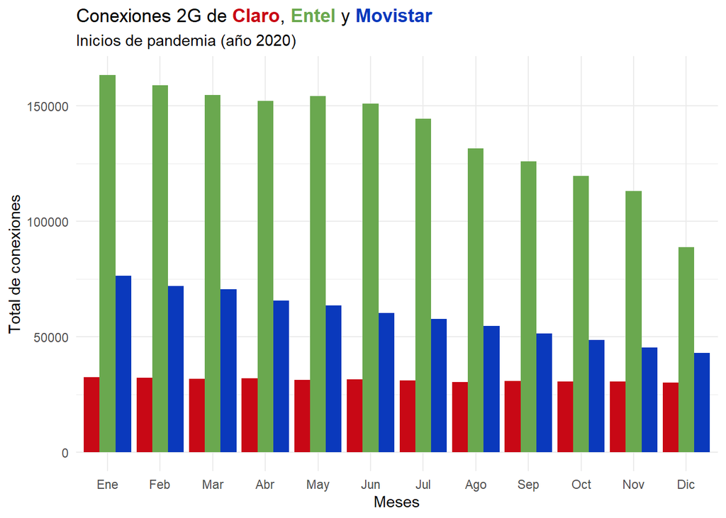

Podemos observar una caida de servicio a internet móvil 2G, por parte de la compañía Entel y Movistar. Una explicación posible es que por producto de el cambio de formate ode las clases a formato en línea muchas personas decidieron contratar internet móvil, ya que en el contexto de la cuarentena volviera dificil la instalación de un modem. En este gráfico no se observa una subida de conexiones, pero esto se debe a que son conexiones 2G, la menor calidad de las que existen actualmente, por lo que muchos usuarios de 2G se cambian a una mejor conexión a internet.

Para comprobar esta teoría, observemos lo que nos dicen los demás gráficos:

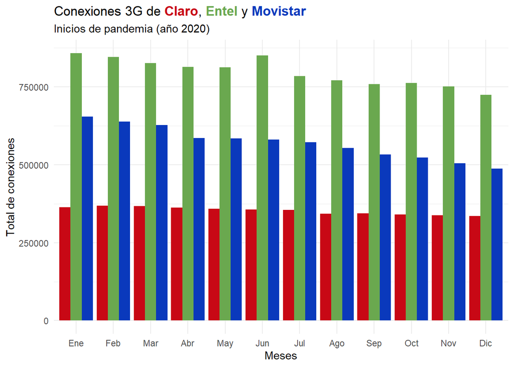

Como vemos, el servicio de 3G, al ser el medio entre la 2G y la 4G, tiene una decaida, pero no tanto como el servicio 2G.

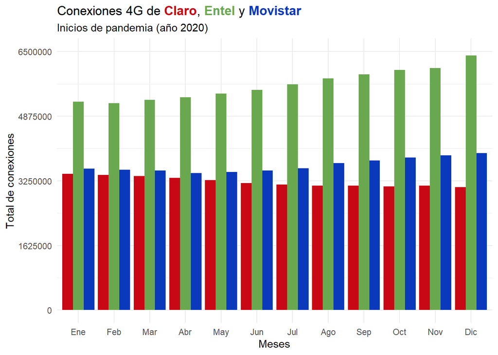